# statistical results on behavioural data (order of session)

Fiona Zhu

10/27/2020

# Introduction

To estimate mean priors from the separate interval groups (the short and long ranges, and mixed ranges. we adopted the left and right spatial separation for the short and long ranges, as used in Roach et al. (2017).

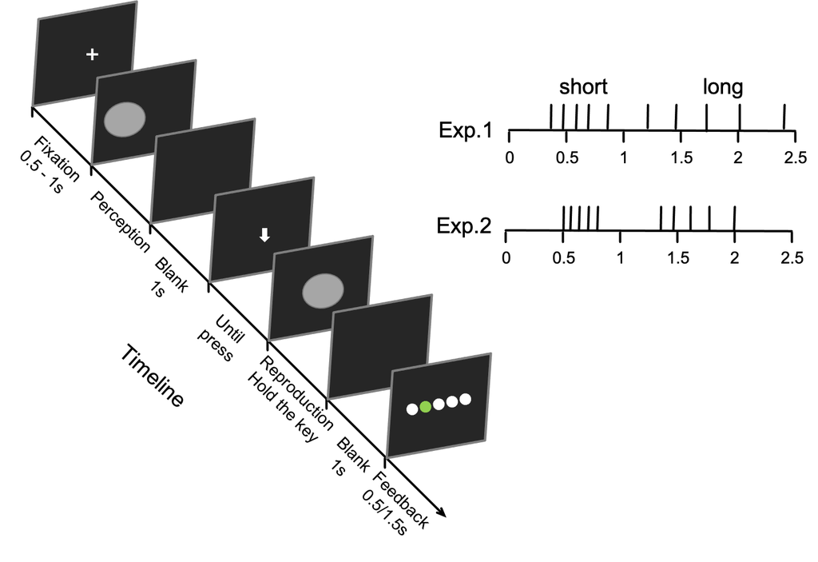

Procedure

# subject information

```r
SubInfo = read.csv(paste0(getwd(), '/data/AllExpSubInfo.csv'))
SummarySubInfo<- SubInfo %>% group_by(Exp) %>%
  dplyr::summarise(mean_Age = mean(Age),
                   n = n(),
                   sd_Age = sd(Age))
SummarySubInfo
```

```
## # A tibble: 2 × 4
##   Exp   mean_Age     n sd_Age
##   <chr>    <dbl> <int>  <dbl>
## 1 Exp1      25.5    16   4.32
## 2 Exp2      24.9    16   2.58
```

```r
F_subInfo <- SubInfo %>% dplyr::filter(Gender == 'F')
SummarySubInfo_F<- F_subInfo %>%
  dplyr::group_by(Exp) %>%
  dplyr::summarise(mean_Age = mean(Age),
                   n = n(),
                   sd_Age = sd(Age))
SummarySubInfo_F
```

```
## # A tibble: 2 × 4
##   Exp   mean_Age     n sd_Age
##   <chr>    <dbl> <int>  <dbl>
## 1 Exp1      25.5    13   4.75
## 2 Exp2      25       5   3.39
```

# load the experiment data

```r
# load all data
allexpdat <- readAllData(paste0(getwd(), '/data/AllExpData.csv'), FALSE, FALSE)
allexpdat$targetDur  <-  round(allexpdat$targetDur,3)

mTargeDur<- allexpdat %>%
  dplyr::group_by(Exp, group) %>%
  dplyr::summarise(mDur = mean(targetDur),
                   n= n(),
                   sdDur = sd(targetDur),
                   seDur = sd(targetDur)/sqrt(n-1))
```

## Experiment 1 (‘gp_loc.m’)

In exp1, there are one practice block and 24 formal blocks. Each block has 20 trials. The duration of the circle displayed on the screen is the interval that participants need to replicate. By pressing left button (Mouse) to reproduce the time duration as long as stimulus was presented. Participants received feedback after their response.

## Experiment 2 (‘gp_loc_ss.m’)

In this experiment, the short and long ranges were clearly separate. The experiment consisted of three sessions with each had 160 trials. The time intervals used in Exp.2 in short group were chosen from 491.2, 542.9, 600, 663, 732.8 ms, and target intervals in long group were chosen from 1.31, 1.45, 1.60, 1.77 and 1.954s. The short (491.2-732.8ms) and long (1310-1954ms) ranges were separated by 577 ms. The order between short group and long group was counterbalanced across participants. The mixed group is always the last session.

In exp2, there are one practice block and 16 formal blocks. Each block has 30 trials. The duration of the circle displayed on the screen is the interval that participants need to replicate. By pressing left button (Mouse) to reproduce the time duration as long as stimulus was presented. Participants received feedback after their response.

```r
# set the previous session
# if the first session equals to current session, then there is no previous session
exps$preSession  = exps$firstSession
#exps[which(exps$group == exps$firstSession & exps$priortype == 'BR'),"preSession"] = 'None'
exps[which(exps$firstSession=='short' & exps$priortype == 'IR'),"preSession"] = 'long'
exps[which(exps$firstSession=='long' & exps$priortype == 'IR'),"preSession"] = 'short'
```

### analysis on previous session (short/long group)

we plot mean reproduction of Experiment 1 and 2 to check the differnece between different session orders.

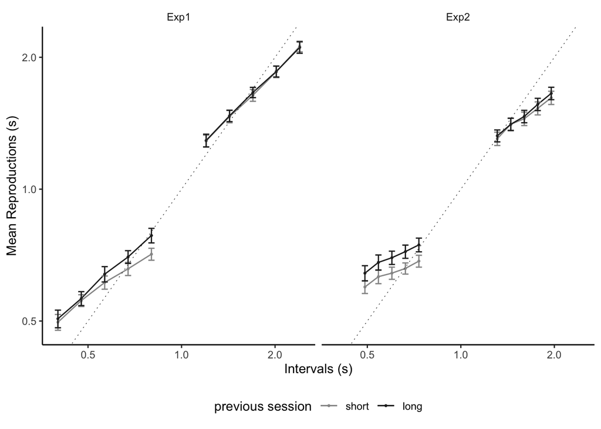

```r
fig_mRP_preSession <- ggplot(sumexp,
       aes(targetDur, m_m_RP, group = interaction(range, preSession), color = preSession)) +
  geom_point(size = 0.5) +
  geom_line(data = sumexp) +
  geom_errorbar(aes(ymin = m_m_RP- m_se_err , ymax = m_m_RP + m_se_err), width = 0.02) +
  geom_abline(slope = 1, linetype=3, size =0.2) + # add diagonal line
  facet_wrap(~Exp) +
  theme_new + scale_color_manual(values = mycolors) +
  theme(strip.background = element_blank()) +
  labs(x = 'Intervals (s)', y = 'Mean Reproductions (s)', color='previous session')+ theme(legend.position='bottom')+
  scale_y_continuous(trans='log10')+ #Transform y axis to log10 scale
  scale_x_continuous(trans='log10') #Transform x axis to log10 scale

ggsave(file.path('figures','fig_mRP_firstsession.png'), fig_mRP_preSession, width = 7, height = 5)

fig_mRP_preSession
```

### order of experiment session (short/long group)

we plot mean reproduction of Experiment 1 and 2 to check the differnece between different session orders.

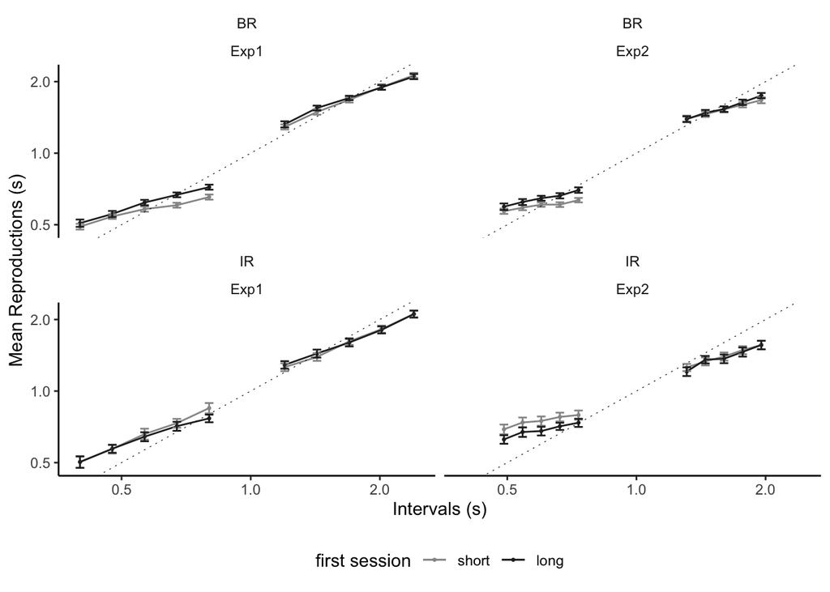

```r
fig_mRP <- ggplot(sumexp,
       aes(targetDur, m_m_RP, group = interaction(priortype, range, firstSession), color = firstSession)) +
  geom_point(size = 0.5) +
  geom_line(data = sumexp) +
  geom_errorbar(aes(ymin = m_m_RP- m_se_err , ymax = m_m_RP + m_se_err), width = 0.02) +
  geom_abline(slope = 1, linetype=3, size =0.2) + # add diagonal line
  facet_wrap(priortype~Exp) +
  theme_new + scale_color_manual(values = mycolors) +
  theme(strip.background = element_blank()) +
  labs(x = 'Intervals (s)', y = 'Mean Reproductions (s)', color='first session')+ theme(legend.position='bottom')+
  scale_y_continuous(trans='log10')+ #Transform y axis to log10 scale
  scale_x_continuous(trans='log10') #Transform x axis to log10 scale

ggsave(file.path('figures','fig_mRP_firstsession.png'), fig_mRP, width = 7, height = 5)

fig_mRP
```

## anova

```r
dat = exps %>% filter(Exp =='Exp2', priortype == 'IR')
dat$firstSession = as.factor(dat$firstSession)
dat$NSub = as.factor(dat$NSub)

mdat_sub <- dat %>%
    dplyr::group_by(targetDur, NSub, firstSession) %>%
    dplyr::summarise(m_RP = mean(RP),
                     m_BIAS = mean(BIAS))
# Two-way mixed ANOVA test
anova_1<- ezANOVA(data = mdat_sub, dv= m_RP, wid =NSub, between = .(firstSession))
```

```
## Coefficient covariances computed by hccm()
```

```r
anova_1
```

```
## $ANOVA
##         Effect DFn DFd        F         p p<.05       ges
## 1 firstSession   1  14 1.956095 0.1836924       0.1225923
##
## $`Levene's Test for Homogeneity of Variance`
##   DFn DFd         SSn        SSd       F         p p<.05
## 1   1  14 0.001990408 0.01091673 2.55257 0.1324334
```

```r
# Effect of group at each time point
one.way <- mdat_sub %>%
  group_by(targetDur) %>%
  anova_test(dv = m_RP, wid = NSub, between = firstSession) %>%
  get_anova_table() %>%
  adjust_pvalue(method = "bonferroni")
```

[output not shown]

```r
one.way
```

```
## # A tibble: 10 × 9
##    targetDur Effect         DFn   DFd       F     p `p<.05`        ges p.adj
##  *     <dbl> <chr>        <dbl> <dbl>   <dbl> <dbl> <chr>        <dbl> <dbl>
##  1     0.491 firstSession     1    14 1.38    0.259 ""      0.09           1
##  2     0.543 firstSession     1    14 0.983   0.338 ""      0.066          1
##  3     0.600 firstSession     1    14 1.58    0.23  ""      0.101          1
##  4     0.663 firstSession     1    14 1.76    0.206 ""      0.112          1
##  5     0.733 firstSession     1    14 2.49    0.137 ""      0.151          1
##  6     1.31  firstSession     1    14 0.817   0.381 ""      0.055          1
##  7     1.45  firstSession     1    14 0.144   0.71  ""      0.01           1
##  8     1.60  firstSession     1    14 0.129   0.724 ""      0.009          1
##  9     1.77  firstSession     1    14 0.077   0.786 ""      0.005          1
## 10     1.95  firstSession     1    14 0.00011 0.992 ""      0.00000784     1
```

## plot scatter reproduction

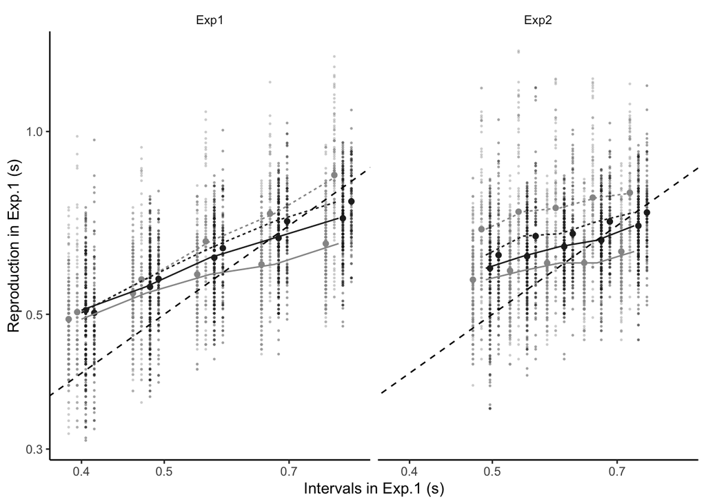

```r
#short group
fig_mRep_scatter_s = ggplot(exps %>% filter(range == 'short'),
                                 aes(targetDur, RP, group = interaction(priortype, firstSession), color = firstSession, linetype = priortype)) +
  geom_point(size = 0.3, position = position_dodge(width = 0.04), alpha=0.3) +
  geom_point(data =sumexp %>% filter(range == 'short'), aes(targetDur, m_m_RP, group = interaction(priortype,firstSession), color = firstSession, linetype = priortype),  position = position_dodge(width = 0.04)) +
  geom_line(data =sumexp%>% filter(range == 'short'), aes(targetDur, m_m_RP, group = interaction(priortype, firstSession), color = firstSession, linetype = priortype))+
  geom_abline(slope = 1, linetype = 2) + # add diagonal line+
  theme_new+
  facet_wrap(~Exp)+
  scale_color_manual(values = mycolors) +
  theme(strip.background = element_blank()) + # remove subtitle background
  labs(x = 'Intervals in Exp.1 (s)', y = 'Reproduction in Exp.1 (s)', color='condition')+
  theme(legend.position = 'none')+
  scale_y_continuous(trans='log10')+ #Transform y axis to log10 scale
  scale_x_continuous(trans='log10') #Transform x axis to log10 scale
fig_mRep_scatter_s
```

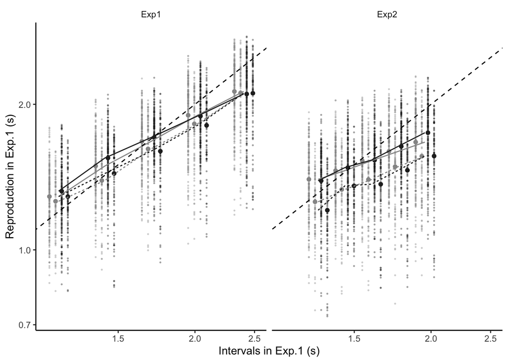

```r
#long group
fig_mRep_scatter_l = ggplot(exps %>% filter(range == 'long'),
                                 aes(targetDur, RP, group = interaction(priortype, firstSession), color = firstSession, linetype = priortype)) +
  geom_point(size = 0.3, position = position_dodge(width = 0.04), alpha=0.3) +
  geom_point(data =sumexp %>% filter(range == 'long'), aes(targetDur, m_m_RP, group = interaction(priortype,firstSession), color = firstSession, linetype = priortype),  position = position_dodge(width = 0.04)) +
  geom_line(data =sumexp%>% filter(range == 'long'), aes(targetDur, m_m_RP, group = interaction(priortype, firstSession), color = firstSession, linetype = priortype))+
  geom_abline(slope = 1, linetype = 2) + # add diagonal line+
  theme_new+
  facet_wrap(~Exp)+
  scale_color_manual(values = mycolors) +
  theme(strip.background = element_blank()) + # remove subtitle background
  labs(x = 'Intervals in Exp.1 (s)', y = 'Reproduction in Exp.1 (s)', color='condition')+
  theme(legend.position = 'none')+
  scale_y_continuous(trans='log10')+ #Transform y axis to log10 scale
  scale_x_continuous(trans='log10') #Transform x axis to log10 scale
fig_mRep_scatter_l
```

## observed CV for each subject

```r
m_expSub <- sumexpSub %>% dplyr::group_by(targetDur, Exp, priortype, range, firstSession) %>%
  dplyr::summarize(m_CV= mean(CV))
```

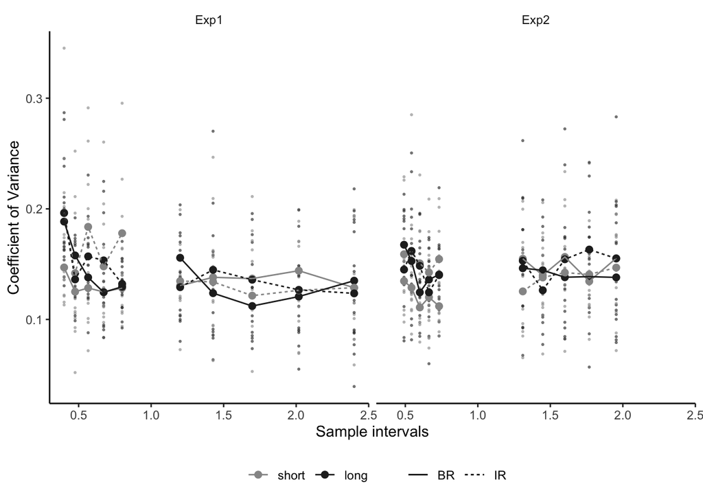

```r
fig_NBIAS_CV_sub= ggplot(sumexpSub, aes(targetDur, CV, group = interaction(priortype, range, firstSession), color = firstSession, linetype = priortype))+
  geom_point(alpha = 0.5, size =0.4)+
  geom_point(m_expSub, mapping = aes(targetDur, m_CV, group = interaction(priortype, range, firstSession), color = firstSession, linetype = priortype), size = 2)+
  geom_line(m_expSub, mapping = aes(targetDur, m_CV, group = interaction(priortype, range, firstSession), color = firstSession, linetype = priortype))+
  theme_new+
  theme(strip.background = element_blank()) + # remove subtitle background
  labs(x = 'Sample intervals', y = 'Coefficient of Variance')+
  theme(legend.position='bottom')+theme(legend.title = element_blank())+
  scale_shape_manual(values=c(15, 16))+
  facet_wrap(~Exp)+
  scale_color_manual(values = mycolors)
fig_NBIAS_CV_sub
```